# Data Science Final Project

Using News Headlines Sentiment Analysis to Predict Stock Prices

# Introduction

Our project aims at investigating how major news sentiment (e.g. new financial regulations, giant companies acquisition or bankruptcy) reported by mass media can influence the volatility of stock market price in U.S., and predict stock market price change affected by important events. This model may be applied by investors, governments, banks and other sectors to evaluate the financial impacts resulting from major events in the news reports.

Data source: - 2014 - 2017 Daily News Headlines of Wall Street Journal (News on 01/01/2017: http://www.wsj.com/public/page/archive-2017-1-1.html) - Daily Dow Jones Stock Price () - Quarterly U.S. GDP (World Bank) - Monthly U.S. Interest Rate (https://fred.stlouisfed.org/tags/series?t=interest+rate%3Bmonthly%3Busa) - Daily NASDQ (https://www.nasdaq.com/aspx/DailyMarketStatistics.aspx) - Monthly U.S. Unemployment Rate (https://data.bls.gov/timeseries/LNS14000000) - Quarterly Company’s Total Assets (https://ycharts.com/dashboard/)

Future work: The topic modeling can be explored more by connecting different topic groups with the change stock price. The percentage change of the stock price has not yet predicted within our analysis. We can evaluate the impacts from news sentiment on the percentage change of the stock price through other machine learning methods in the future.

# News Headline Sentiment Analysis

Below is the sentiment analysis for the news headlines. We first collect the key words from the news headlines on the Wall Street Journal by day and clean the data through removing the stop words and blank tokens. According to the sentiment dictionary, all the key words are identified as “positive” or “negative”. After assigning the “positive” as 1 and “negative” as 0, we can calculate the daily average sentiment of news. From 2014 to 2017, the overall average sentiment of all the news is around 0.46.

```r
knitr::opts_chunk$set(echo = TRUE)

#####################################
# News Headline Sentiment Analysis  #
#####################################

library(rio)
github.url <- "https://github.com/VivianSihanZHENG/Final-Project/blob/master/"
file.url <- "rawnews.RData?raw=true"
news <- import(paste0(github.url, file.url))

library(tidytext) #for easy text manipulation
library(SnowballC) #for stemming words
library(NLP)
library(tm)
library(dplyr)

# Get a sentiment dictionary
dict <- get_sentiments("bing")

# Parse your text
# Create date formate
toks <- news %>%
  unnest_tokens(word, abstract)  %>%
  mutate(word = wordStem(word))

toks$date <- as.Date(toks$date,"%Y-%m-%d")

#Remove stopwords and blank tokens
data(stop_words)
toks <- toks %>%
  anti_join(stop_words)

#Get Average Sentiment
toks <- toks %>% inner_join(dict)

senti_character <- as.character(toks$sentiment)
senti_character <- gsub("negative","0", senti_character)
senti_character <- gsub("positive","1", senti_character)
toks$senti <- as.numeric(senti_character)

senti_bydate <- aggregate(toks$senti, by = list(date = toks$date), FUN = mean)
colnames(senti_bydate)[which(names(senti_bydate) == "x")] <- "avg.senti"
```

# Load Stock Data

The Dow Jones industrial average (DJIA) includes 30 of America’s largest companies from a wide range of industries. Thus, we loaded these 30 companies’ daily stock price information, including opening and closing price. The direction and percentage of change are also included in the data frame to evaluate the vitality of stock price.

```r
###################
##Load stock data##
###################

#Set Working Directory to Locate the 30 Companies' Data
##Need data path change
setwd("/Users/shirleyfu/Desktop/Dow Jones")

#Get the File List
##Need data path change
files <- list.files(path = "/Users/shirleyfu/Desktop/Dow Jones", recursive = TRUE,
                    pattern = "\\.csv$", full.names = FALSE)

# Loop the data frame consisting all 30 companies' data
data2=lapply(files, read.csv, header=TRUE, sep=",")
data_rbind <- do.call("rbind", data2)

#Change the data type of Date as Date
data_rbind$date <- as.Date(data_rbind$date, format = "%Y-%m-%d")

#Get a new column of Year & Month so that we can subset the data for Year 2017
data_rbind$Year <- as.numeric(format(data_rbind$date, "%Y"))
data_rbind$Month <- as.numeric(format(data_rbind$date, "%m"))

#Generate a new data frame of year 2015-2017
data_4yrs <- subset(data_rbind, data_rbind$Year == 2017 | data_rbind$Year == 2016 | data_rbind$Year == 2015 | data_rbind$Year == 2014)


#Create a new column of the status of price change, using open price
data_4yrs$ChangeOpening <- NA
data_4yrs$ChangeClose <- NA
data_4yrs$pctopen <- NA
data_4yrs$pctclose <- NA


firm_total <- data.frame(date = as.Date(NA),
                         open = NA,
                         close = NA,
                         name = NA,
                         ChangeOpening = NA,
                         ChangeClose = NA,
                         pctopen = NA,
                         pctclose = NA)


#calculate opening price change
firmlist <- unique(data_4yrs$Name)

for (i in firmlist){
  firm <- data_4yrs[data_4yrs$Name == i, c("date","open","close","ChangeOpening","ChangeClose","pctopen","pctclose")]

  #open price change
  for (j in 2:nrow(firm)){
    if (firm$open[j] > firm$open[j-1]){
      firm$ChangeOpening[j-1] <- "increase"
    } else if (firm$open[j] <= firm$open[j-1]){
      firm$ChangeOpening[j-1] <- "decrease"
    }
  }

  #close price change
  for (j in 2:nrow(firm)){
    if (firm$close[j] > firm$close[(j-1)]){
      firm$ChangeClose[j] <- "increase"
    } else if (firm$close[j] <= firm$close[j-1]){
      firm$ChangeClose[j] <- "decrease"
    }
  }

  #percentage change
  for (j in 2:nrow(firm)){
    firm$pctopen[j-1] <- (firm$open[j] - firm$open[j-1])/firm$open[j-1] *100
    firm$pctclose[j] <- (firm$close[j] - firm$close[j-1])/firm$close[j-1] *100
  }

  firm$name <- i
  firm_total <- rbind(firm_total, firm)
}

firm_total <- firm_total[-1,]
```

# Data Visualization I

## Stock Pirce

Below is the data visualization of the stock price change of 30 companies from 2014 to 2017.

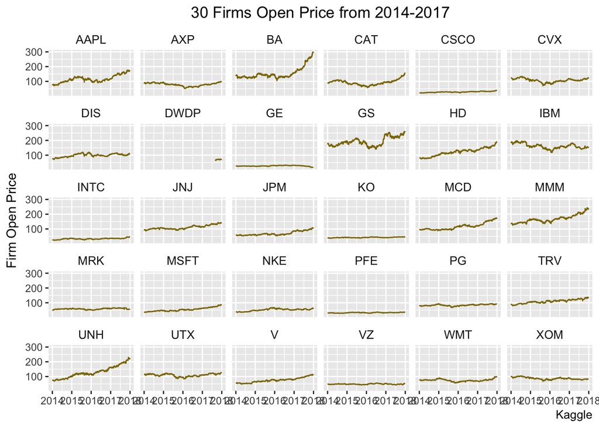

```r
#######################
##Line Graph 30 Firms##
#######################

#2014-17 Stock Open Price
library(ggplot2)

ggplot(data = firm_total)+
  geom_line(mapping = aes(x=date,y=open),
                                     color="gold4")+
  facet_wrap(~name,ncol=6)+
  theme(strip.background = element_blank(),
        strip.text.x = element_text(size = 10),
        axis.title.x=element_blank()) +
  #scale_x_continuous(breaks = c(2015, 2018))+
  labs(y = "Firm Open Price", caption = "Kaggle") +
  ggtitle("30 Firms Open Price from 2014-2017") +
  theme(plot.title = element_text(hjust = 0.5))
```

[figure not shown]

```r
#2014-17 Stock Close Price

ggplot(data = firm_total)+
  geom_line(mapping = aes(x=date,y=close),
            color="gold4")+
  facet_wrap(~name,ncol=6)+
  theme(strip.background = element_blank(),
        strip.text.x = element_text(size = 10),
        axis.title.x=element_blank()) +
  labs(y = "Firm Close Price", caption = "Kaggle") +
  ggtitle("30 Firms Close Price from 2014-2017") +
  theme(plot.title = element_text(hjust = 0.5))
```

According to the above graphs, we can find that Boeing (BA), UnitedHealth (UNH), 3M (MMM) and McDonald’s (MCD) have experienced rapid growth during this period. Goldman Sachs(GS), Chevron (CVX) and IBM (IBM) have seen more fluctuations than other companies.

# Merge News Sentiment With Stock Price By Date

Below is the process to combine the news sentiment and stock price by date. We also added GDP, interest rate, NASDQ, unemployment rate and company total assets into the data frame as the control variables.

```r
#################################################
# Merge news sentiment with stock price by date #
#################################################

sentiment_stock <- merge(senti_bydate, firm_total, by = "date", all = TRUE)
sentiment_stock <- na.omit(sentiment_stock)
sentiment_stock$month <- as.numeric(format(sentiment_stock$date, "%m"))

sentiment_stock$ChangeOpening <- as.factor(sentiment_stock$ChangeOpening)
sentiment_stock$ChangeClose <- as.factor(sentiment_stock$ChangeClose)

sentiment_stock$quarter <- ceiling(as.numeric(sentiment_stock$month) / 3)
sentiment_stock$year <- as.numeric(format(sentiment_stock$date, "%Y"))


#merge with GDP

#Load gdp
library(rio)
github.url <- "https://github.com/VivianSihanZHENG/Final-Project/blob/master/"
file.url <- "gdp.xlsx?raw=true"

gdp <- import(paste0(github.url, file.url))
gdp$quarter <- gsub("Q","", gdp$quarter)
gdp <- gdp[,-3]
gdp$quarter <- as.numeric(gdp$quarter)
sentiment_stock <- merge(sentiment_stock, gdp, by = c("year","quarter"))


#Interest rate
file.url <- "interest.xlsx?raw=true"
interest <- import(paste0(github.url, file.url))

colnames(interest)[which(names(interest) == "rate")] <- "interest.rate"
interest$interest.rate <- as.numeric(interest$interest.rate)
interest$year <- as.numeric(format(interest$date,"%Y"))
interest$month <- as.numeric(format(interest$date,"%m"))
interest <- interest[,-1]
sentiment_stock <- merge(sentiment_stock, interest, by = c("year","month"))


#NASDQ
file.url <- "NASDQ.xlsx?raw=true"
NASDQ <- import(paste0(github.url, file.url))

colnames(NASDQ)[which(names(NASDQ) == "Date")] <- "date"
colnames(NASDQ)[which(names(NASDQ) == "Open")] <- "open_nasdq"
colnames(NASDQ)[which(names(NASDQ) == "Close")] <- "close_nasdq"
NASDQ <- NASDQ[,c("date", "open_nasdq","close_nasdq")]
NASDQ$date <- as.Date(NASDQ$date)
sentiment_stock <- merge(sentiment_stock, NASDQ, by = "date")


#unemp
file.url <- "unemployment.xlsx?raw=true"
unemp <- import(paste0(github.url, file.url))

sentiment_stock$month <- as.numeric(sentiment_stock$month)
sentiment_stock <- merge(sentiment_stock, unemp, by = c("year","month"))


#assets
file.url <- "asset.xlsx?raw=true"
asset<- import(paste0(github.url, file.url))
asset$name <- toupper(asset$name)
sentiment_stock <- merge(sentiment_stock, asset, by = c("year","quarter","name"))
```

# SVM Models

Below is the SVM models that predict the change of the stock price by the news sentiments. With the control of GDP, interest rate, unemployment rate, NASDAQ and company total assets, we use the positive and negative news sentiments to predict whether the price on that day would increase or not.

```r
###################
##SUPPORT VECTORS##
###################
#Load svm libraries
library(e1071)

train <- sentiment_stock[(sentiment_stock$avg.senti > 0.65 | sentiment_stock$avg.senti < 0.35), ] # only keep sentiment > 0.65 or < 0.35
train.positive <- sentiment_stock[sentiment_stock$avg.senti > 0.5, ]  # only keep positive sentiment
train.negative <- sentiment_stock[sentiment_stock$avg.senti < 0.5, ]  # only keep negative sentiment

subfile <- c("train","train.positive","train.negative")

#train <- sentiment_stock[sentiment_stock$year == 2015 | sentiment_stock$year == 2016, ]
#test <- sentiment_stock[sentiment_stock$year == 2017,]


# Function that creates k folds
  kfolds <- function(k){
    #
    #Desc: Assign each record to one of the k-folds
    #
    #Args:
    #  k = number of folds
    #
    #Returns:
    #  a vector of the partition assignments
    #
    train$vec <- runif(nrow(train)) # ramdonly assign each observation with a random number
    train$kfold <-  cut(train$vec, breaks = k, label = FALSE) # randomly assign observations into k groups according to the random numbers
    return(train)
  }
  train <- cbind(train, kfolds(5))
  colnames(train)[grep("kfolds", names(train))] <- "kfold"

  kfolds <- function(k){
    #
    #Desc: Assign each record to one of the k-folds
    #
    #Args:
    #  k = number of folds
    #
    #Returns:
    #  a vector of the partition assignments
    #
    train.positive$vec <- runif(nrow(train.positive)) # ramdonly assign each observation with a random number
    train.positive$kfold <-  cut(train.positive$vec, breaks = k, label = FALSE) # randomly assign observations into k groups according to the random numbers
    return(train.positive)
  }
  train.positive <- cbind(train.positive, kfolds(5))
  colnames(train.positive)[grep("kfolds", names(train.positive))] <- "kfold"


  kfolds <- function(k){
    #
    #Desc: Assign each record to one of the k-folds
    #
    #Args:
    #  k = number of folds
    #
    #Returns:
    #  a vector of the partition assignments
    #
    train.negative$vec <- runif(nrow(train.negative)) # ramdonly assign each observation with a random number
    train.negative$kfold <-  cut(train.negative$vec, breaks = k, label = FALSE) # randomly assign observations into k groups according to the random numbers
    return(train.negative)
  }
  train.negative <- cbind(train.negative, kfolds(5))
  colnames(train.negative)[grep("kfolds", names(train.negative))] <- "kfold"


#Load F1 Score
meanf1 <- function(actual, predicted){

  #Mean F1 score function
  #actual = a vector of actual labels
  #predicted = predicted labels

  classes <- unique(actual)
  results <- data.frame()
  for(k in classes){
    results <- rbind(results,
                     data.frame(class.name = k,
                                weight = sum(actual == k)/length(actual),
                                precision = sum(predicted == k & actual == k)/sum(predicted == k),
                                recall = sum(predicted == k & actual == k)/sum(actual == k)))
  }
  results$score <- results$weight * 2 * (results$precision * results$recall) / (results$precision + results$recall)
  return(sum(results$score))
}


scores <- data.frame()
for (i in unique(train$kfold)){
  #Fit SVM  under default assumptions -- cost = 1, gamma = 0.055
  #svm.rbf.fit <- svm(ChangeOpening ~ avg.senti + name + growth + interest.rate + unemployment + open_nasdq,
  #                   data = train[train$folds != i, ], kernel = "radial",
  #                   cost = 1, gamma = 0.05555)

  #Tools to review output
  #print(svm.rbf.fit)

  #Calibrate SVMs
  pred.test <- svm(ChangeOpening ~ avg.senti + growth + interest.rate + unemployment + open_nasdq + assets,
                   data = train[train$kfold != i, ], kernel = "radial", cost = 1, gamma = 8)
  print(pred.test)

  #Predict
  pred.rbf <- predict(pred.test, train[train$kfold == i, ])
  scores <- rbind(scores, data.frame(model = "SVM",
                                     actual = train[train$kfold == i, ]$ChangeOpening,
                                     predicted = pred.rbf))
  #examine result
  table(pred.rbf)
}
```

```
##
## Call:
## svm(formula = ChangeOpening ~ avg.senti + growth + interest.rate +
##     unemployment + open_nasdq + assets, data = train[train$kfold !=
##     i, ], kernel = "radial", cost = 1, gamma = 8)
##
##
## Parameters:
##    SVM-Type:  C-classification
##  SVM-Kernel:  radial
##        cost:  1
##       gamma:  8
##
## Number of Support Vectors:  2066
##
##
## Call:
## svm(formula = ChangeOpening ~ avg.senti + growth + interest.rate +
##     unemployment + open_nasdq + assets, data = train[train$kfold !=
##     i, ], kernel = "radial", cost = 1, gamma = 8)
##
##
## Parameters:
##    SVM-Type:  C-classification
##  SVM-Kernel:  radial
##        cost:  1
##       gamma:  8
##
## Number of Support Vectors:  2059
##
##
## Call:
## svm(formula = ChangeOpening ~ avg.senti + growth + interest.rate +
##     unemployment + open_nasdq + assets, data = train[train$kfold !=
##     i, ], kernel = "radial", cost = 1, gamma = 8)
##
##
## Parameters:
##    SVM-Type:  C-classification
##  SVM-Kernel:  radial
```

[output cut: 19 more lines]

```
##
##
## Call:
## svm(formula = ChangeOpening ~ avg.senti + growth + interest.rate +
##     unemployment + open_nasdq + assets, data = train[train$kfold !=
##     i, ], kernel = "radial", cost = 1, gamma = 8)
##
##
## Parameters:
##    SVM-Type:  C-classification
##  SVM-Kernel:  radial
##        cost:  1
##       gamma:  8
##
## Number of Support Vectors:  2045
```

```r
meanf1(scores$actual, scores$predicted)
```

```
## [1] 0.708848
```

```r
#negative sentiment
scores.negative <- data.frame()
for (i in unique(train.negative$kfold)){
  #Fit SVM  under default assumptions -- cost = 1, gamma = 0.055
  #svm.rbf.fit <- svm(ChangeOpening ~ avg.senti + name + growth + interest.rate + unemployment + open_nasdq,
  #                   data = train[train$folds != i, ], kernel = "radial",
  #                   cost = 1, gamma = 0.05555)

  #Tools to review output
  #print(svm.rbf.fit)

  #Calibrate SVMs
  pred.test <- svm(ChangeOpening ~ avg.senti + growth + interest.rate + unemployment + open_nasdq + assets,
                   data = train.negative[train.negative$kfold != i, ], kernel = "radial", cost = 1, gamma = 8)
  print(pred.test)

  #Predict
  pred.rbf <- predict(pred.test, train.negative[train.negative$kfold == i, ])
  scores.negative <- rbind(scores.negative, data.frame(model = "SVM",
                                            actual = train.negative[train.negative$kfold == i, ]$ChangeOpening,
                                            predicted = pred.rbf))
  #examine result
  table(pred.rbf)
}
```

```
##
## Call:
## svm(formula = ChangeOpening ~ avg.senti + growth + interest.rate +
##     unemployment + open_nasdq + assets, data = train.negative[train.negative$kfold !=
##     i, ], kernel = "radial", cost = 1, gamma = 8)
##
##
## Parameters:
##    SVM-Type:  C-classification
##  SVM-Kernel:  radial
##        cost:  1
##       gamma:  8
##
## Number of Support Vectors:  14110
##
##
## Call:
## svm(formula = ChangeOpening ~ avg.senti + growth + interest.rate +
##     unemployment + open_nasdq + assets, data = train.negative[train.negative$kfold !=
##     i, ], kernel = "radial", cost = 1, gamma = 8)
##
##
## Parameters:
##    SVM-Type:  C-classification
##  SVM-Kernel:  radial
##        cost:  1
##       gamma:  8
##
## Number of Support Vectors:  14080
##
##
## Call:
## svm(formula = ChangeOpening ~ avg.senti + growth + interest.rate +
##     unemployment + open_nasdq + assets, data = train.negative[train.negative$kfold !=
##     i, ], kernel = "radial", cost = 1, gamma = 8)
##
##
## Parameters:
##    SVM-Type:  C-classification
##  SVM-Kernel:  radial
```

[output cut: 19 more lines]

```
##
##
## Call:
## svm(formula = ChangeOpening ~ avg.senti + growth + interest.rate +
##     unemployment + open_nasdq + assets, data = train.negative[train.negative$kfold !=
##     i, ], kernel = "radial", cost = 1, gamma = 8)
##
##
## Parameters:
##    SVM-Type:  C-classification
##  SVM-Kernel:  radial
##        cost:  1
##       gamma:  8
##
## Number of Support Vectors:  14011
```

```r
meanf1(scores.negative$actual, scores.negative$predicted)
```

```
## [1] 0.6415974
```

```r
#positive sentiment
scores.positive <- data.frame()
for (i in unique(train.positive$kfold)){
  #Fit SVM  under default assumptions -- cost = 1, gamma = 0.055
  #svm.rbf.fit <- svm(ChangeOpening ~ avg.senti + name + growth + interest.rate + unemployment + open_nasdq,
  #                   data = train[train$folds != i, ], kernel = "radial",
  #                   cost = 1, gamma = 0.05555)

  #Tools to review output
  #print(svm.rbf.fit)

  #Calibrate SVMs
  pred.test <- svm(ChangeOpening ~ avg.senti + growth + interest.rate + unemployment + open_nasdq + assets,
                   data = train.positive[train.positive$kfold != i, ], kernel = "radial", cost = 1, gamma = 8)
  print(pred.test)

  #Predict
  pred.rbf <- predict(pred.test, train.positive[train.positive$kfold == i, ])
  scores.positive <- rbind(scores.positive, data.frame(model = "SVM",
                                                       actual = train.positive[train.positive$kfold == i, ]$ChangeOpening,
                                                       predicted = pred.rbf))
  #examine result
  table(pred.rbf)
}
```

```
##
## Call:
## svm(formula = ChangeOpening ~ avg.senti + growth + interest.rate +
##     unemployment + open_nasdq + assets, data = train.positive[train.positive$kfold !=
##     i, ], kernel = "radial", cost = 1, gamma = 8)
##
##
## Parameters:
##    SVM-Type:  C-classification
##  SVM-Kernel:  radial
##        cost:  1
##       gamma:  8
##
## Number of Support Vectors:  460
##
##
## Call:
## svm(formula = ChangeOpening ~ avg.senti + growth + interest.rate +
##     unemployment + open_nasdq + assets, data = train.positive[train.positive$kfold !=
##     i, ], kernel = "radial", cost = 1, gamma = 8)
##
##
## Parameters:
##    SVM-Type:  C-classification
##  SVM-Kernel:  radial
##        cost:  1
##       gamma:  8
##
## Number of Support Vectors:  470
##
##
## Call:
## svm(formula = ChangeOpening ~ avg.senti + growth + interest.rate +
##     unemployment + open_nasdq + assets, data = train.positive[train.positive$kfold !=
##     i, ], kernel = "radial", cost = 1, gamma = 8)
##
##
## Parameters:
##    SVM-Type:  C-classification
##  SVM-Kernel:  radial
```

[output cut: 19 more lines]

```
##
##
## Call:
## svm(formula = ChangeOpening ~ avg.senti + growth + interest.rate +
##     unemployment + open_nasdq + assets, data = train.positive[train.positive$kfold !=
##     i, ], kernel = "radial", cost = 1, gamma = 8)
##
##
## Parameters:
##    SVM-Type:  C-classification
##  SVM-Kernel:  radial
##        cost:  1
##       gamma:  8
##
## Number of Support Vectors:  477
```

```r
meanf1(scores.negative$actual, scores.negative$predicted)
```

```
## [1] 0.6415974
```

```r
#Close price
scores.close <- data.frame()
for (i in unique(train$kfold)){
  #Fit SVM  under default assumptions -- cost = 1, gamma = 0.055
  #svm.rbf.fit <- svm(ChangeOpening ~ avg.senti + name + growth + interest.rate + unemployment + open_nasdq,
  #                   data = train[train$folds != i, ], kernel = "radial",
  #                   cost = 1, gamma = 0.05555)

  #Tools to review output
  #print(svm.rbf.fit)

  #Calibrate SVMs
  pred.test.close <- svm(ChangeClose ~ avg.senti + growth + interest.rate + unemployment + close_nasdq + assets,
                         data = train[train$kfold != i, ], kernel = "radial", cost = 1, gamma = 8)
  print(pred.test.close)

  #Predict
  pred.rbf.close <- predict(pred.test.close, train[train$kfold == i, ])
  scores.close <- rbind(scores.close, data.frame(model = "SVM",
                                                 actual = train[train$kfold == i, ]$ChangeClose,
                                                 predicted = pred.rbf.close))
  #examine result
  table(pred.rbf.close)
}
```

```
##
## Call:
## svm(formula = ChangeClose ~ avg.senti + growth + interest.rate +
##     unemployment + close_nasdq + assets, data = train[train$kfold !=
##     i, ], kernel = "radial", cost = 1, gamma = 8)
##
##
## Parameters:
##    SVM-Type:  C-classification
##  SVM-Kernel:  radial
##        cost:  1
##       gamma:  8
##
## Number of Support Vectors:  2097
##
##
## Call:
## svm(formula = ChangeClose ~ avg.senti + growth + interest.rate +
##     unemployment + close_nasdq + assets, data = train[train$kfold !=
##     i, ], kernel = "radial", cost = 1, gamma = 8)
##
##
## Parameters:
##    SVM-Type:  C-classification
##  SVM-Kernel:  radial
##        cost:  1
##       gamma:  8
##
## Number of Support Vectors:  2113
##
##
## Call:
## svm(formula = ChangeClose ~ avg.senti + growth + interest.rate +
##     unemployment + close_nasdq + assets, data = train[train$kfold !=
##     i, ], kernel = "radial", cost = 1, gamma = 8)
##
##
## Parameters:
##    SVM-Type:  C-classification
##  SVM-Kernel:  radial
```

[output cut: 19 more lines]

```
##
##
## Call:
## svm(formula = ChangeClose ~ avg.senti + growth + interest.rate +
##     unemployment + close_nasdq + assets, data = train[train$kfold !=
##     i, ], kernel = "radial", cost = 1, gamma = 8)
##
##
## Parameters:
##    SVM-Type:  C-classification
##  SVM-Kernel:  radial
##        cost:  1
##       gamma:  8
##
## Number of Support Vectors:  2091
```

```r
meanf1(scores.close$actual, scores.close$predicted)
```

```
## [1] 0.6898794
```

The Mean F1 Score for the sentiments predication on the open price change is around 70%.

# Decision Tree

## Decision Tree for All the 30 Companies Together

Decision tree model is applied to predict the change of opening price of all companies. The input features of decision tree model include news sentiments, GDP, interest rate, unemployment rate, NASDAQ and company total assets.

```r
#####################################################
###Decision Tree for All the 30 Companies Together###
#####################################################

library(rpart)
scores2 <- data.frame()
for (i in unique(train$kfold)){

  # Refit with optimal
  # cp = 0
  fit.0 <- rpart(ChangeOpening ~ avg.senti + name + growth +
                   interest.rate + unemployment + open_nasdq + assets,
                 method = "class", data = train[train$kfold != i, ], cp = 0)
  # printcp(fit.0)
  # Put all cp into a data frame
  fit.0.df <- as.data.frame(printcp(fit.0))
  # Find the optimal cp
  a <- min(fit.0.df$xerror)
  b <- subset(fit.0.df, xerror == a)[, 5]
  c <- a + b
  d <- max(fit.0.df$xerror[fit.0.df$xerror <= c])
  cp.opt <- max(subset(fit.0.df, xerror == d)[, 1])

  # Run the optimal decision tree
  fit.opt <- rpart(ChangeOpening ~ avg.senti + growth +
                     interest.rate + unemployment + open_nasdq + assets,
                   method = "class", data = train[train$kfold != i, ], cp = cp.opt)

  # Predict values for test set
  pred.opt.test <- predict(fit.opt, train[train$kfold == i, ], type='class')
  scores2 <- rbind(scores2, data.frame(model = "Decision Tree",
                                       actual = train[train$kfold == i, ]$ChangeOpening,
                                       predicted = pred.opt.test))
  #examine result
  #table(pred.rbf)
}
```

```
##
## Classification tree:
## rpart(formula = ChangeOpening ~ avg.senti + name + growth + interest.rate +
##     unemployment + open_nasdq + assets, data = train[train$kfold !=
##     i, ], method = "class", cp = 0)
##
## Variables actually used in tree construction:
## [1] assets        avg.senti     growth        interest.rate name
## [6] open_nasdq    unemployment
##
## Root node error: 1449/3013 = 0.48092
##
## n= 3013
##
##            CP nsplit rel error  xerror     xstd
```

[output cut: 216 more lines]

```r
meanf1(scores2$actual, scores2$predicted)
```

```
## [1] 0.7471759
```

```r
#Determine which variable had the greatest influence
fit.opt$variable.importance
```

```
##    open_nasdq     avg.senti  unemployment        growth interest.rate
##     311.49166     236.10418     146.51024      86.65032      33.46400
##        assets
##      30.06390
```

## Decision Tree for Individual Company

*DowDuPont (DWDP)’s open price information is not complete in the data frame.

```r
##########################################
###Decision Tree for Individual Company###
##########################################

library(rpart)
##variable importance at company level
tree.importance <- function(){

  results <- c()
  importance <- data.frame()

  scores2 <- data.frame()
  for (i in unique(train$kfold)){
    for (j in unique(train$name)){

      scores2 <- data.frame()
      train1 <- train[train$name != j, ]

      # Refit with optimal
      # cp = 0
      fit.0 <- rpart(ChangeOpening ~ avg.senti + name + growth +
                       interest.rate + unemployment + open_nasdq + assets,
                     method = "class", data = train1[train1$kfold != i, ], cp = 0)
      # printcp(fit.0)
      # Put all cp into a data frame
      fit.0.df <- as.data.frame(printcp(fit.0))
      # Find the optimal cp
      a <- min(fit.0.df$xerror)
      b <- subset(fit.0.df, xerror == a)[, 5]
      c <- a + b
      d <- max(fit.0.df$xerror[fit.0.df$xerror <= c])
      cp.opt <- max(subset(fit.0.df, xerror == d)[, 1])

      # Run the optimal decision tree
      fit.opt <- rpart(ChangeOpening ~ avg.senti + growth + interest.rate +
                         unemployment + open_nasdq + assets,
                       method = "class", data = train1[train1$kfold != i, ], cp = cp.opt)

      #importance <- rbind(importance, fit.opt$variable.importance)
      import <- as.data.frame(print(fit.opt$variable.importance))
      importance <- rbind(importance, import)
    }
    return(importance)
  }
}

tree.firm29 <- tree.importance()
```

```
##
## Classification tree:
## rpart(formula = ChangeOpening ~ avg.senti + name + growth + interest.rate +
##     unemployment + open_nasdq + assets, data = train1[train1$kfold !=
##     i, ], method = "class", cp = 0)
##
## Variables actually used in tree construction:
## [1] assets        avg.senti     growth        interest.rate name
## [6] open_nasdq    unemployment
##
## Root node error: 1401/2913 = 0.48095
##
## n= 2913
##
##            CP nsplit rel error  xerror     xstd
## 1  0.05032120      0   1.00000 1.00000 0.019248
## 2  0.04175589      2   0.89936 0.95575 0.019199
## 3  0.03783012      4   0.81585 0.88651 0.019052
## 4  0.02498216      5   0.77802 0.82156 0.018834
## 5  0.02391149      7   0.72805 0.80942 0.018784
## 6  0.01784440      9   0.68023 0.76588 0.018582
## 7  0.01284797     11   0.64454 0.71877 0.018322
## 8  0.00975494     12   0.63169 0.67809 0.018060
## 9  0.00880324     15   0.60243 0.66667 0.017980
## 10 0.00678087     20   0.55389 0.65953 0.017929
## 11 0.00642398     22   0.54033 0.64597 0.017828
## 12 0.00571021     25   0.52034 0.64168 0.017795
## 13 0.00499643     28   0.50321 0.64811 0.017844
## 14 0.00428266     37   0.45325 0.65525 0.017897
## 15 0.00392577     41   0.43612 0.64954 0.017855
## 16 0.00356888     43   0.42827 0.65168 0.017871
## 17 0.00309303     44   0.42470 0.64954 0.017855
## 18 0.00285510     50   0.40614 0.64954 0.017855
## 19 0.00249822     55   0.39186 0.65096 0.017865
## 20 0.00214133     59   0.38187 0.64168 0.017795
## 21 0.00190340     68   0.36260 0.63812 0.017768
## 22 0.00166548     71   0.35689 0.63954 0.017779
## 23 0.00142755     75   0.34975 0.63954 0.017779
## 24 0.00118963     86   0.33333 0.63597 0.017751
## 25 0.00107066     89   0.32976 0.63597 0.017751
```

[output cut: 1381 more lines]

```
## 21 0.00238607     55   0.40014 0.62419 0.017687
## 22 0.00229062     65   0.37581 0.62348 0.017681
## 23 0.00214746     71   0.36077 0.61990 0.017652
## 24 0.00143164     81   0.33930 0.61274 0.017593
## 25 0.00119303     89   0.32785 0.61918 0.017646
## 26 0.00107373     92   0.32427 0.61346 0.017599
## 27 0.00083512     94   0.32212 0.61489 0.017611
## 28 0.00071582    102   0.31496 0.62706 0.017710
## 29 0.00035791    106   0.31210 0.63350 0.017761
## 30 0.00023861    110   0.31067 0.63422 0.017767
## 31 0.00000000    113   0.30995 0.63923 0.017806
##    open_nasdq     avg.senti  unemployment        growth interest.rate
##     324.85473     316.06457     169.49044     120.55475      69.61296
##        assets
##      54.32910
```

```r
x2 <- as.data.frame(rep(c(1, 2, 3, 4, 5, 6, 7, 8, 9, 10, 11, 12, 13, 14, 15, 16, 17, 18, 19,
                          20, 21, 22, 23, 24, 25, 26, 27, 28, 29), each = 6))
tree.firm29 <- cbind(tree.firm29, x2)
colnames(tree.firm29) <- c("importance", "number")

##Print company name
for (j in unique(train$name))
  firm <- as.data.frame(as.character(unique(train$name)))
colnames(firm) <- c("firm")
x1 <- as.data.frame(c(1, 2, 3, 4, 5, 6, 7, 8, 9, 10, 11, 12, 13, 14, 15, 16, 17, 18, 19,
                      20, 21, 22, 23, 24, 25, 26, 27, 28, 29))
colnames(x1) <- c("number")
firm.name <- cbind(firm, x1)

#Total companies' name and their decision tree variable importance
company.importance <- merge(firm.name, tree.firm29, by = "number")


##meanf1
meanf1.company <- function(){

  results <- data.frame()

  scores2 <- data.frame()
  for (i in unique(train$kfold)){
    for (j in unique(train$name)){

      scores2 <- data.frame()
      train1 <- train[train$name != j, ]

      # Refit with optimal
      # cp = 0
      fit.0 <- rpart(ChangeOpening ~ avg.senti + name + growth +
                       interest.rate + unemployment + open_nasdq + assets,
                     method = "class", data = train1[train1$kfold != i, ], cp = 0)
      # printcp(fit.0)
      # Put all cp into a data frame
      fit.0.df <- as.data.frame(printcp(fit.0))
      # Find the optimal cp
      a <- min(fit.0.df$xerror)
      b <- subset(fit.0.df, xerror == a)[, 5]
      c <- a + b
      d <- max(fit.0.df$xerror[fit.0.df$xerror <= c])
      cp.opt <- max(subset(fit.0.df, xerror == d)[, 1])

      # Run the optimal decision tree
      fit.opt <- rpart(ChangeOpening ~ avg.senti + growth + interest.rate +
                         unemployment + open_nasdq + assets,
                       method = "class", data = train1[train1$kfold != i, ], cp = cp.opt)

      # Predict values for test set
      pred.opt.test <- predict(fit.opt, train1[train1$kfold == i, ], type='class')
      scores2 <- rbind(scores2, data.frame(model = "Decision Tree",
                                           actual = train1[train1$kfold == i, ]$ChangeOpening,
                                           predicted = pred.opt.test))

      # Mean F1
      mean.data <- meanf1(scores2$actual, scores2$predicted)
      # Append
      results <- rbind(results, mean.data)
      colnames(results) <- "meanf1"
    }
    return(results)
  }
}

meanf1.firm29 <- meanf1.company()
```

```
##
## Classification tree:
## rpart(formula = ChangeOpening ~ avg.senti + name + growth + interest.rate +
##     unemployment + open_nasdq + assets, data = train1[train1$kfold !=
##     i, ], method = "class", cp = 0)
##
## Variables actually used in tree construction:
## [1] assets        avg.senti     growth        interest.rate name
## [6] open_nasdq    unemployment
##
## Root node error: 1401/2913 = 0.48095
##
## n= 2913
##
##            CP nsplit rel error  xerror     xstd
```

[output cut: 1305 more lines]

```r
#View(meanf1.firm29)

#Set a data frame the same long as 29 firms
x2 <- as.data.frame(c(1, 2, 3, 4, 5, 6, 7, 8, 9, 10, 11, 12, 13, 14, 15, 16, 17, 18, 19,
                      20, 21, 22, 23, 24, 25, 26, 27, 28, 29))
colnames(x2) <- c("number")
meanf1.firm29 <- cbind(meanf1.firm29, x2)

#Total companies' name, their decision tree variable importance, and their meanf1
company.importance.total <- merge(company.importance, meanf1.firm29, by = "number")
company.importance.total1 <- company.importance.total[, -3]
company.importance.total2 <- cbind(company.importance.total1, tree.firm29)[, -5]
#View(company.importance.total2)

company.importance.total2$names <- rownames(company.importance.total2)

#Chart of meanf1 and variable importance in each firm
company.importance.total3 <- data.frame(names = row.names(company.importance.total2), company.importance.total2)[, -6]
company.importance.total3
```

```
##                           names number firm    meanf1 importance
## avg.senti             avg.senti      1 AAPL 0.7330988 287.287989
## open_nasdq           open_nasdq      1 AAPL 0.7330988 266.844724
## unemployment       unemployment      1 AAPL 0.7330988 137.180346
## growth                   growth      1 AAPL 0.7330988  83.420415
## interest.rate     interest.rate      1 AAPL 0.7330988  25.907394
## assets                   assets      1 AAPL 0.7330988   4.223363
## avg.senti1           avg.senti1      2  AXP 0.6836941 264.821893
## open_nasdq1         open_nasdq1      2  AXP 0.6836941 242.725414
## unemployment1     unemployment1      2  AXP 0.6836941 145.959689
## growth1                 growth1      2  AXP 0.6836941  71.089889
## interest.rate1   interest.rate1      2  AXP 0.6836941  32.603784
## assets1                 assets1      2  AXP 0.6836941   2.759345
## avg.senti2           avg.senti2      3   BA 0.7304052 314.473078
## open_nasdq2         open_nasdq2      3   BA 0.7304052 305.835109
## unemployment2     unemployment2      3   BA 0.7304052 155.234989
## growth2                 growth2      3   BA 0.7304052 117.426042
## assets2                 assets2      3   BA 0.7304052  41.301305
## interest.rate2   interest.rate2      3   BA 0.7304052  39.706612
## avg.senti3           avg.senti3      4  CAT 0.7196448 314.468021
## open_nasdq3         open_nasdq3      4  CAT 0.7196448 295.409696
## unemployment3     unemployment3      4  CAT 0.7196448 173.830916
## growth3                 growth3      4  CAT 0.7196448 114.138578
## assets3                 assets3      4  CAT 0.7196448  64.597795
## interest.rate3   interest.rate3      4  CAT 0.7196448  54.358933
## avg.senti4           avg.senti4      5 CSCO 0.7363373 300.607310
## open_nasdq4         open_nasdq4      5 CSCO 0.7363373 256.239007
## unemployment4     unemployment4      5 CSCO 0.7363373 113.011827
## growth4                 growth4      5 CSCO 0.7363373 105.799921
## interest.rate4   interest.rate4      5 CSCO 0.7363373  18.578312
## assets4                 assets4      5 CSCO 0.7363373   2.673690
## avg.senti5           avg.senti5      6  CVX 0.7144549 318.301116
## open_nasdq5         open_nasdq5      6  CVX 0.7144549 317.189012
## unemployment5     unemployment5      6  CVX 0.7144549 169.753709
## growth5                 growth5      6  CVX 0.7144549 121.277564
## interest.rate5   interest.rate5      6  CVX 0.7144549  51.134368
## assets5                 assets5      6  CVX 0.7144549  48.737296
## avg.senti6           avg.senti6      7  DIS 0.6238881 334.535311
## open_nasdq6         open_nasdq6      7  DIS 0.6238881 331.547060
## unemployment6     unemployment6      7  DIS 0.6238881 175.317081
```

[output cut: 120 more lines]

```
## growth26               growth26     27   VZ 0.7511200 114.053510
## interest.rate26 interest.rate26     27   VZ 0.7511200  61.176454
## assets26               assets26     27   VZ 0.7511200   6.229428
## avg.senti27         avg.senti27     28  WMT 0.7263684 298.255815
## open_nasdq27       open_nasdq27     28  WMT 0.7263684 283.891807
## unemployment27   unemployment27     28  WMT 0.7263684 137.518637
## growth27               growth27     28  WMT 0.7263684  92.748418
## interest.rate27 interest.rate27     28  WMT 0.7263684  42.951666
## assets27               assets27     28  WMT 0.7263684   5.755101
## open_nasdq28       open_nasdq28     29  XOM 0.7588351 324.854728
## avg.senti28         avg.senti28     29  XOM 0.7588351 316.064566
## unemployment28   unemployment28     29  XOM 0.7588351 169.490442
## growth28               growth28     29  XOM 0.7588351 120.554747
## interest.rate28 interest.rate28     29  XOM 0.7588351  69.612956
## assets28               assets28     29  XOM 0.7588351  54.329105
```

# Data Visualization II

## Topic Modeling

Following the topic modeling that categorize all the key words in the headlines into different topic groups.

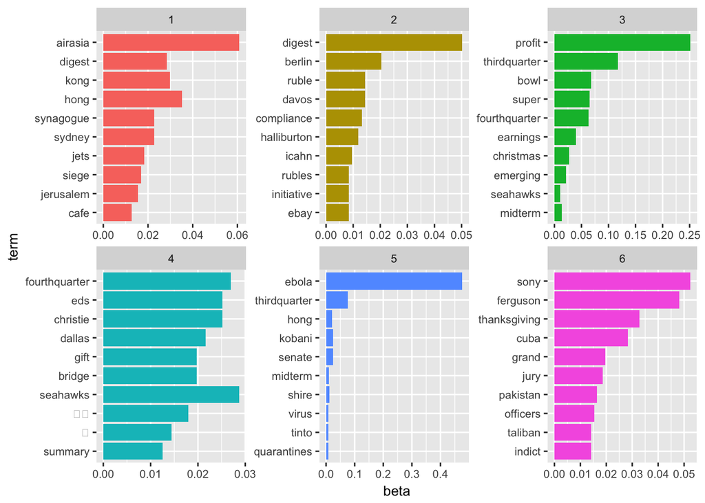

```r
####################
###TOPIC MODELING###
####################

#Count words
news.count <- news %>%
  unnest_tokens(word, abstract) %>%
  count(date, word, sort = TRUE)  %>%
  anti_join(stop_words)
#Calculate TF-IDF
news.count <- news.count %>%
  bind_tf_idf(word, date, n)

#News.count by year
news.count1 <- subset(news.count, news.count$date <= "2014-12-31")
news.count2 <- subset(news.count, news.count$date >= "2015-1-1" & news.count$date <= "2015-12-31")
news.count3 <- subset(news.count, news.count$date >= "2016-1-1" & news.count$date <= "2016-12-31")
news.count4 <- subset(news.count, news.count$date >= "2017-1-1" & news.count$date <= "2017-12-31")

#######################
#Topic Modeling in 2014
week <- c("monday","tuesday","wednesday","thursday","friday","saturday","sunday")
for (i in week){
  news.count1 <- subset(news.count1, news.count1$word != i)
}

year <- c("jan", "feb", "mar", "apr", "may", "jun", "jul", "aug", "sep", "sept", "oct",
          "nov", "dec", "january", "february", "march", "april", "may", "june",
          "july", "august", "september", "october","november", "december")
for (j in year){
  news.count1 <- subset(news.count1, news.count1$word != j)
}

#Keep top 10 TFIDF by group
news.count.top1 <- news.count1 %>%
  group_by(date) %>%
  top_n(n = 10, wt = tf_idf)
#Create Document Term Matrix
news.matrix1 <- news.count.top1 %>% cast_dtm(date, word, n)

#LDA
library(topicmodels)
library(ggplot2)

##LDA: Latent Dirichlet Allocaiton
#Run LDA
tal_lda1 <- LDA(news.matrix1, k = 6, control = list(seed = 1234))
tal_top1 <- tidy(tal_lda1, matrix = "beta")

#
tal_top_terms1 <- tal_top1 %>%
  group_by(topic) %>%
  top_n(10, beta) %>%
  ungroup() %>%
  arrange(topic, -beta)

tal_top_terms1 %>%
  mutate(term = reorder(term, beta)) %>%
  ggplot(aes(term, beta, fill = factor(topic))) +
  geom_col(show.legend = FALSE) +
  theme(text = element_text(size=10)) +
  facet_wrap(~ topic, scales = "free") +
  coord_flip()
```

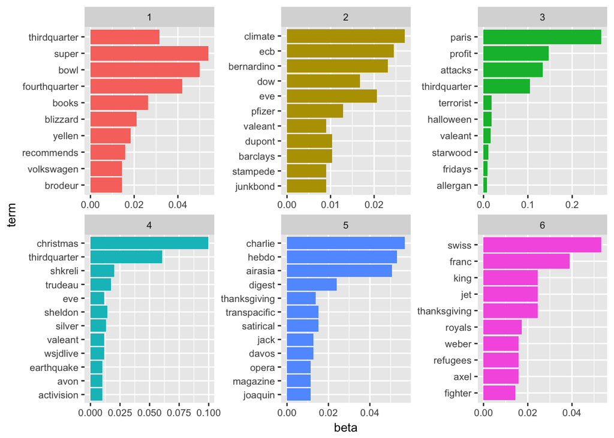

```r
#######################
#Topic Modeling in 2015
week <- c("monday","tuesday","wednesday","thursday","friday","saturday","sunday")
for (i in week){
  news.count2 <- subset(news.count2, news.count2$word != i)
}

year <- c("jan", "feb", "mar", "apr", "may", "jun", "jul", "aug", "sep", "sept", "oct",
          "nov", "dec", "january", "february", "march", "april", "may", "june",
          "july", "august", "september", "october","november", "december")
for (j in year){
  news.count2 <- subset(news.count2, news.count2$word != j)
}

#Keep top 10 TFIDF by group
news.count.top2 <- news.count2 %>%
  group_by(date) %>%
  top_n(n = 10, wt = tf_idf)
#Create Document Term Matrix
news.matrix2 <- news.count.top2 %>% cast_dtm(date, word, n)

#LDA
library(topicmodels)
library(ggplot2)

##LDA: Latent Dirichlet Allocaiton
#Run LDA
tal_lda2 <- LDA(news.matrix2, k = 6, control = list(seed = 1234))
tal_top2 <- tidy(tal_lda2, matrix = "beta")

#
tal_top_terms2 <- tal_top2 %>%
  group_by(topic) %>%
  top_n(10, beta) %>%
  ungroup() %>%
  arrange(topic, -beta)

tal_top_terms2 %>%
  mutate(term = reorder(term, beta)) %>%
  ggplot(aes(term, beta, fill = factor(topic))) +
  geom_col(show.legend = FALSE) +
  theme(text = element_text(size=10)) +
  facet_wrap(~ topic, scales = "free") +
  coord_flip()
```

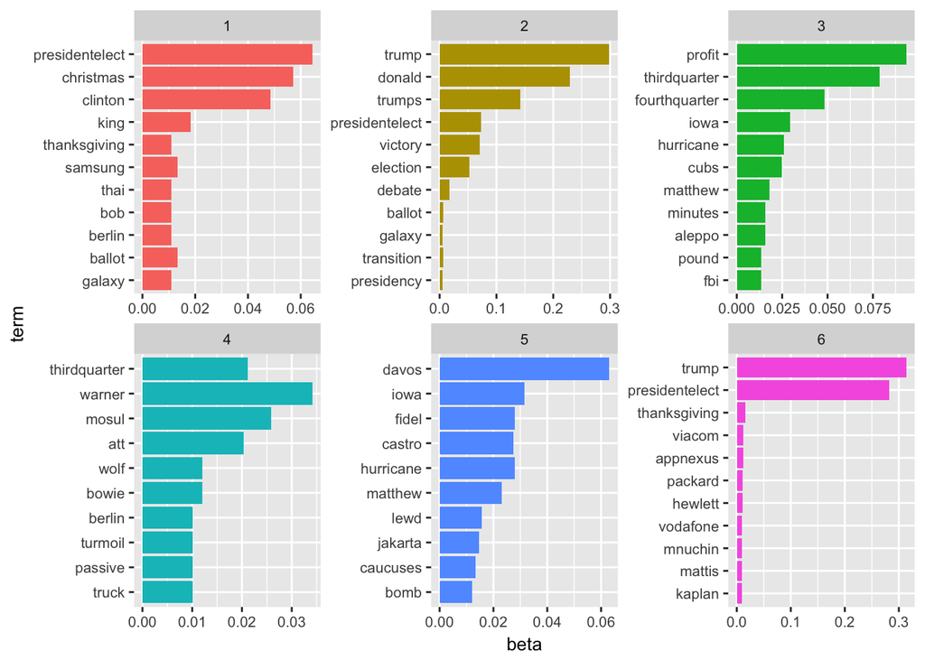

```r
#######################
#Topic Modeling in 2016
week <- c("monday","tuesday","wednesday","thursday","friday","saturday","sunday")
for (i in week){
  news.count3 <- subset(news.count3, news.count3$word != i)
}

year <- c("jan", "feb", "mar", "apr", "may", "jun", "jul", "aug", "sep", "sept", "oct",
          "nov", "dec", "january", "february", "march", "april", "may", "june",
          "july", "august", "september", "october","november", "december")
for (j in year){
  news.count3 <- subset(news.count3, news.count3$word != j)
}

#Keep top 10 TFIDF by group
news.count.top3 <- news.count3 %>%
  group_by(date) %>%
  top_n(n = 10, wt = tf_idf)
#Create Document Term Matrix
news.matrix3 <- news.count.top3 %>% cast_dtm(date, word, n)

#LDA
library(topicmodels)
library(ggplot2)

##LDA: Latent Dirichlet Allocaiton
#Run LDA
tal_lda3 <- LDA(news.matrix3, k = 6, control = list(seed = 1234))
tal_top3 <- tidy(tal_lda3, matrix = "beta")

#
tal_top_terms3 <- tal_top3 %>%
  group_by(topic) %>%
  top_n(10, beta) %>%
  ungroup() %>%
  arrange(topic, -beta)

tal_top_terms3 %>%
  mutate(term = reorder(term, beta)) %>%
  ggplot(aes(term, beta, fill = factor(topic))) +
  geom_col(show.legend = FALSE) +
  theme(text = element_text(size=10)) +
  facet_wrap(~ topic, scales = "free") +
  coord_flip()
```

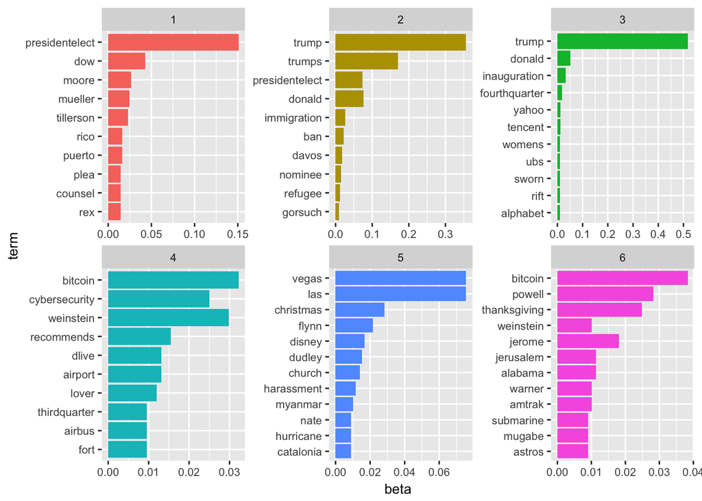

```r
#######################
#Topic Modeling in 2017
week <- c("monday","tuesday","wednesday","thursday","friday","saturday","sunday")
for (i in week){
  news.count4 <- subset(news.count4, news.count4$word != i)
}

year <- c("jan", "feb", "mar", "apr", "may", "jun", "jul", "aug", "sep", "sept", "oct",
          "nov", "dec", "january", "february", "march", "april", "may", "june",
          "july", "august", "september", "october","november", "december")
for (j in year){
  news.count4 <- subset(news.count4, news.count4$word != j)
}

#Keep top 10 TFIDF by group
news.count.top4 <- news.count4 %>%
  group_by(date) %>%
  top_n(n = 10, wt = tf_idf)
#Create Document Term Matrix
news.matrix4 <- news.count.top4 %>% cast_dtm(date, word, n)

#LDA
library(topicmodels)
library(ggplot2)

##LDA: Latent Dirichlet Allocaiton
#Run LDA
tal_lda4 <- LDA(news.matrix4, k = 6, control = list(seed = 1234))
tal_top4 <- tidy(tal_lda4, matrix = "beta")

#
tal_top_terms4 <- tal_top4 %>%
  group_by(topic) %>%
  top_n(10, beta) %>%
  ungroup() %>%
  arrange(topic, -beta)

tal_top_terms4 %>%
  mutate(term = reorder(term, beta)) %>%
  ggplot(aes(term, beta, fill = factor(topic))) +
  geom_col(show.legend = FALSE) +
  theme(text = element_text(size=10)) +
  facet_wrap(~ topic, scales = "free") +
  coord_flip()
```

## WordCloud

The word cloud shows the key words that have the highest frequency from 2014 to 2017.

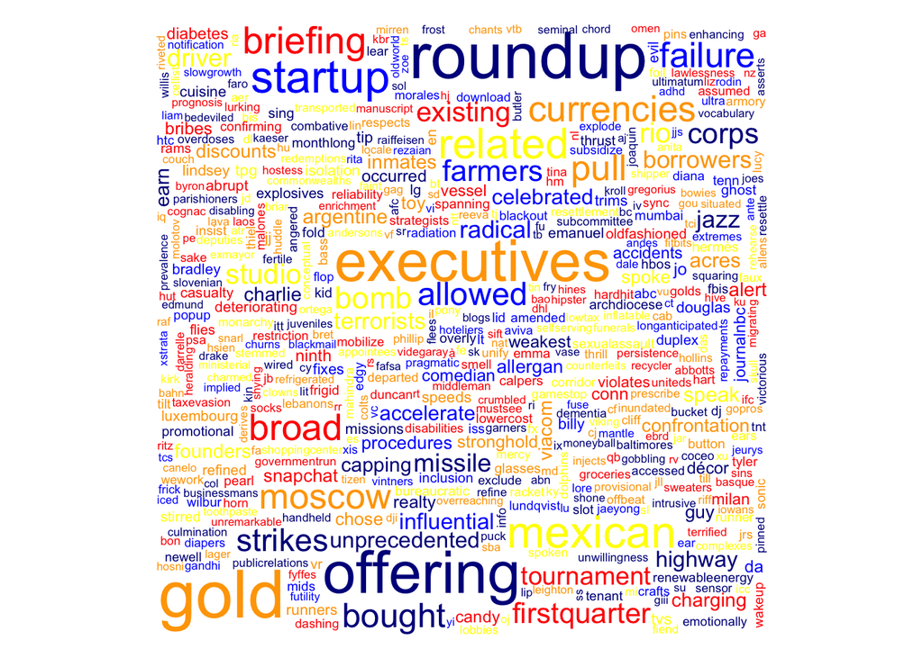

```r
#############
##Wordcloud##
#############
#Wordcloud all news key words from 2014-17
library(RColorBrewer)
library(wordcloud)

# Calculate Frequency
#uniwords <- unique(news.count$word)

#WordCloud2014-2017
news.word <- aggregate(news.count$n, by = list(date = news.count$word), FUN = length)
colnames(news.word) <- c("word", "frequency")

# Use worldcloud to scale each reason
wordcloud(news.word$word, 100 * news.word$frequency,
          min.freq = 1000, max.words = Inf,
          colors = c("red", "yellow", "blue", "orange", "dark blue"),
          random.color = T)
```